# Microeconomics 1021A

11/09/2020

## Content

- Intro
- OWL & Mylab
- Graphs

## Intro

- TA name: Hans Martinez.
- You can call me Hans
- Textbook is required (Can be second hand)
- Mylab is required (Can be bought separately from the book)
- Health measures: Wear masks & social distance

## OWL & Mylab

- OWL: Syllabus, lectures, forums, Mylab help
  - https://owl.uwo.ca/portal
- Mylab: Practice questions and quizzes
  - Course ID: streufert46445
  - https://www.pearsonmylabandmastering.com/northamerica/

## Expectations

- Questions about class, OWL and Mylab: OWL Forums & Professor
- Questions about tutorial, tutorial questions: TA

## Graphs

Problems 15A, 15B, 16 and 17 (p. 32)

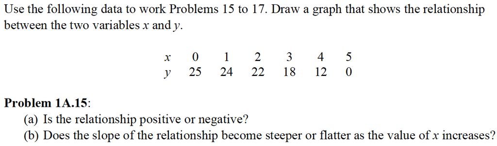

## Solution

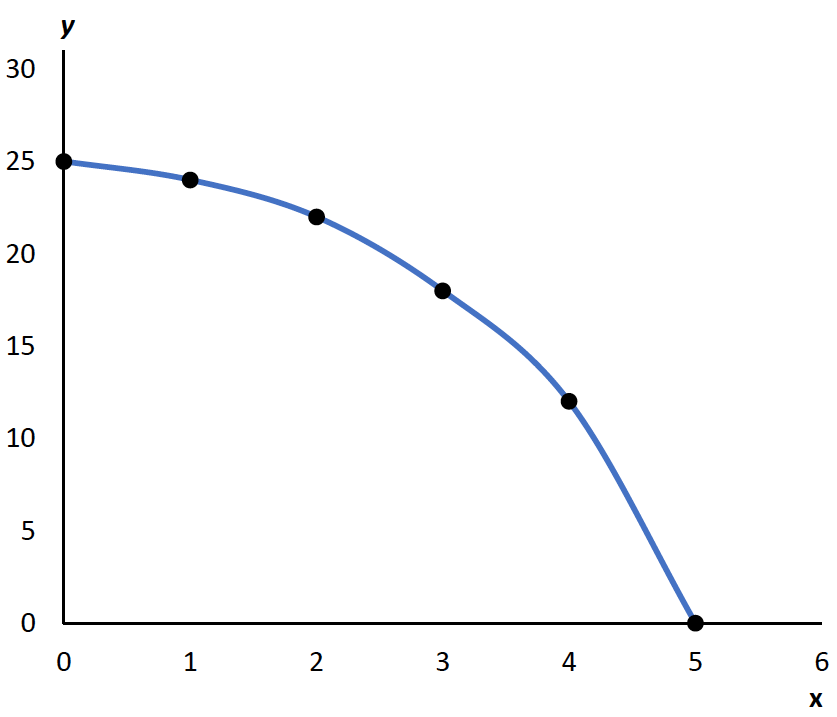

## Question 16

Calculate the slope of the relationship between *x* and *y* when *x* equals 3.

## Question 16

Calculate the slope of the relationship between *x* and *y* when *x* equals 3.

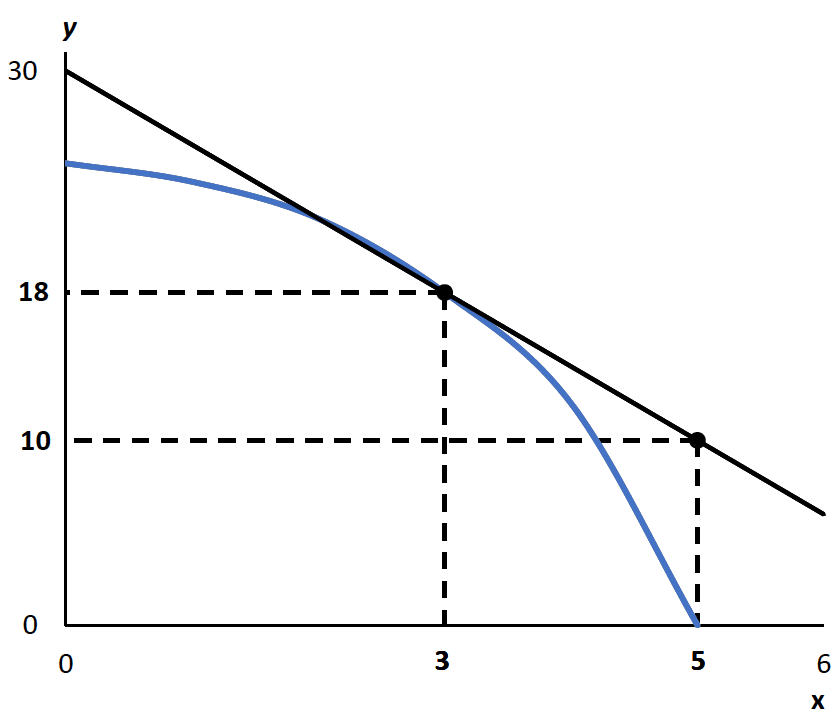

## Question 17

Calculate the slope of the relationship across the arc as x increases from 4 to 5.

## Question 17

Calculate the slope of the relationship across the arc as x increases from 4 to 5.

[figure not shown]

## Recap

- Relaionship between two vars:
  - Positive: Move in same direction (upward slope)
  - Negative: Move in opposite directions (downward slope)
- Given two points (\(x_1, y_1\)) and (\(x_2,y_2\)),
  - the slope is \(\frac{\Delta y}{\Delta x} = \frac{y_2-y_1}{x_2-x_1}\)